# 每週一圖作業

#### 環境設定

以下為老師執行時一定會存在的環境設定

```r
library(dplyr); library(stringr); library(ggplot2); library(plotly); library(lubridate); library(readr); library(tidyr); library(showtext)
font_add("QYuan","cwTeXQYuan-Medium.ttf") # 新增字體
showtext_auto(enable=TRUE) #啟用字體
theme_set(theme_classic())
knitr::opts_chunk$set(out.width='80%', fig.asp=.75, fig.align='center', fig.showtext=T)
```

#### 資料處理

此部份在做：

- 原始Rda資料引入（即引入**dataList**物件）；
- 資料清理成作圖用graphData物件。

請將你最原始的資料連同作業一起上傳到作業上傳網址：  
* 若「原始資料為網頁下載」，且下載指令寫在data cleaning chunk裡的話，可以不用上傳「資料」。  
* 若原始資料有很多個檔案，請先引入成data frame並存在「一個」.Rda檔裡上傳（如`example_data.Rda`檔）。

資料檔引入到進入作圖前的資料處理請寫在下面區塊，分二部份：

- 資料處理
- 作圖用資料物件生成(最後形成作圖資料物件graphData)

```r
library(readr)
loan=read_csv("https://ws.moe.edu.tw/001/Upload/4/relfile/0/4764/a27e7193-392e-4780-9133-f27d3a65c791.csv",
              locale = locale(encoding = "BIG5"))
str(loan$項目) #查看項目的
```

```
##  chr [1:42] "貸款人次" "貸款人數" "貸款金額（元）" "貸款人次" ...
```

```r
貸款人次 = loan[loan$項目 == "貸款人次", ]
貸款金額 = loan[loan$項目 == "貸款金額（元）", ]

貸款人次1= data.frame(貸款人次[,1],
                      貸款人次[,3:6]/10000) #每萬人
貸款金額1 =data.frame(貸款金額[,1],
                      貸款金額[,3:6]/100000000) #每千萬元
平均每人貸款金額0=data.frame(貸款金額[,1],
                            貸款人次[,3:6],
                            貸款金額[,3:6]/10000) #每萬元/人

平均每人貸款金額1=data.frame(貸款金額[,1],
  平均每人貸款金額0$公立大專校院.1/平均每人貸款金額0$公立大專校院,
  平均每人貸款金額0$私立大專校院.1/平均每人貸款金額0$私立大專校院,
  平均每人貸款金額0$公立高中職.1/平均每人貸款金額0$公立高中職,
  平均每人貸款金額0$私立高中職.1/平均每人貸款金額0$私立高中職)
names(平均每人貸款金額1)[2:5] <-c("公立大專校院", "私立大專校院", "公立高中職", "私立高中職")
```

#### 繪圖程式

```r
library(reshape2)
```

```r
人次 = melt(貸款人次1,id.vars="學年度")
figure_人次=ggplot(人次,
                   aes(x=學年度,
                       y=value)) +
            geom_line(aes(color=variable))

graphData1 = figure_人次 +
       geom_hline(aes(yintercept=10)) +
       geom_vline(aes(xintercept=98),
                      colour="#BB0000",
                      linetype="dashed") +
       labs(title = '貸款人次/萬人')

金額 = melt(貸款金額1,
            id.vars="學年度")
figure_金額=ggplot(金額,
                   aes(x=學年度,
                       y=value)) +
                   geom_line(aes(color=variable))

graphData2 = figure_金額 +
       geom_hline(aes(yintercept=10)) +
       geom_vline(aes(xintercept=98),
                      colour="#BB0000",
                      linetype="dashed") +
       labs(title = '貸款金額/千萬元')

平均貸款金額= melt(平均每人貸款金額1,
                   id.vars="學年度")
figure_平均貸款金額 = ggplot(平均貸款金額,
                             aes(x=學年度,
                                 y=value)) +
                      geom_line(aes(color=variable))
graphData3 = figure_平均貸款金額 +
       geom_hline(aes(yintercept=10)) +
       geom_vline(aes(xintercept=100),
                      colour="#BB0000",
                      linetype="dashed") +
       labs(title = '平均貸款金額/元')
```

#### 設計說明

說明想傳達的訊息（必要）及設計想法（非必要）。寫在*之後*

此資料為92-105學年度高級中等以上學校學生申請就學貸款人次、人數及貸款金額。

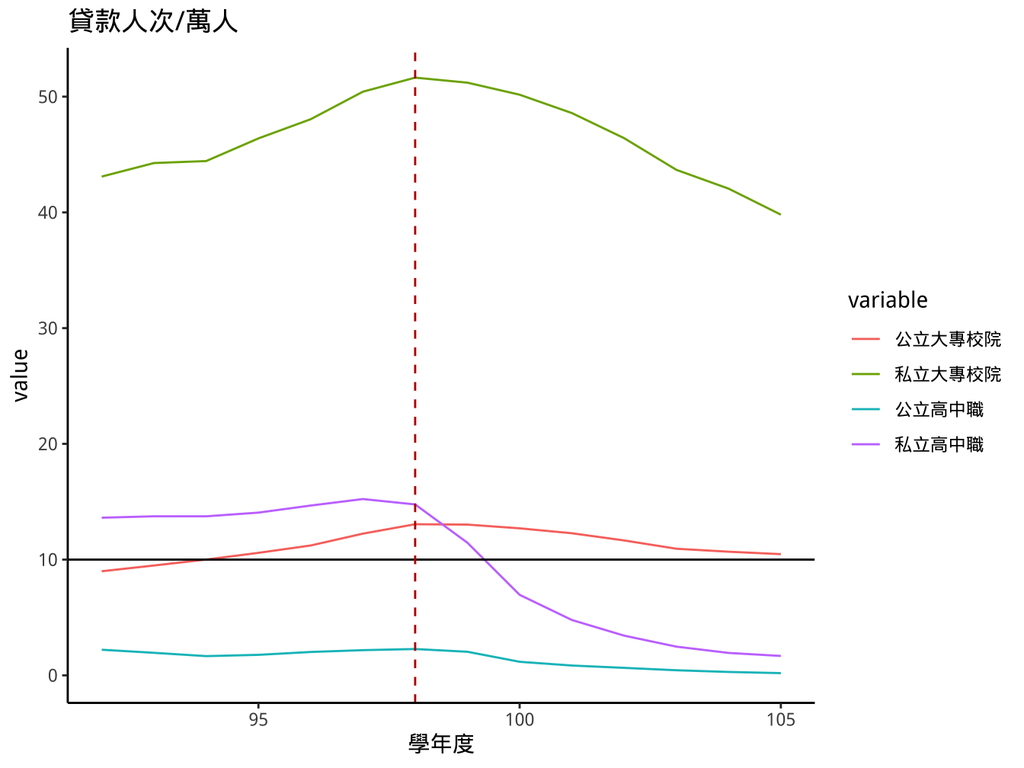

```r
graphData1
```

graphData1為貸款人次，各教育體制約在98學年度時，貸款人次逐年下降；

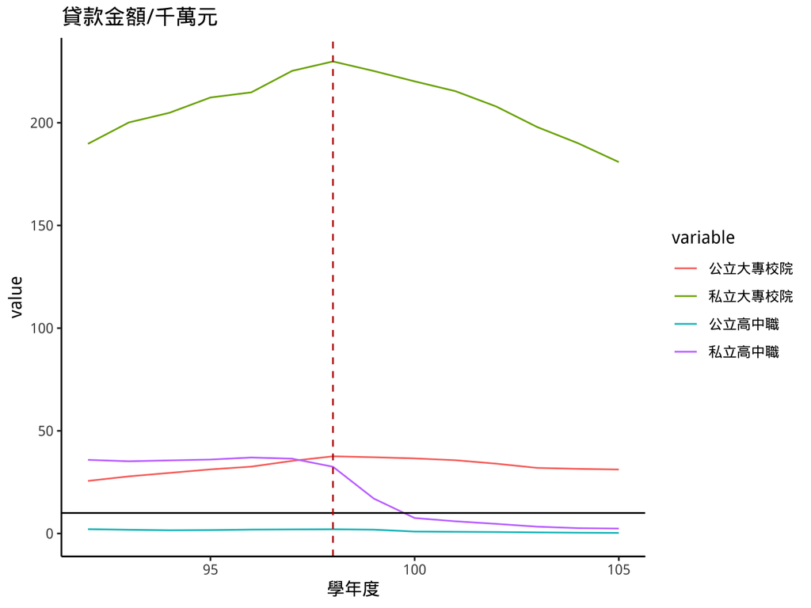

```r
graphData2
```

graphData2為貸款金額，各教育體制也約在98學年度時，貸款金額下降，此結果相當直覺，貸款人次逐年下降，總貸款金額下降是可以理解的； 從graphData1跟graphData2的結果，也許我們會推測每人平均貸款金額可能下降或持平，尤其是高中職體系於103學年度開始實施12年國教，學費的降低，直覺來講應會讓更多家庭負擔得起、貸款金額降低。

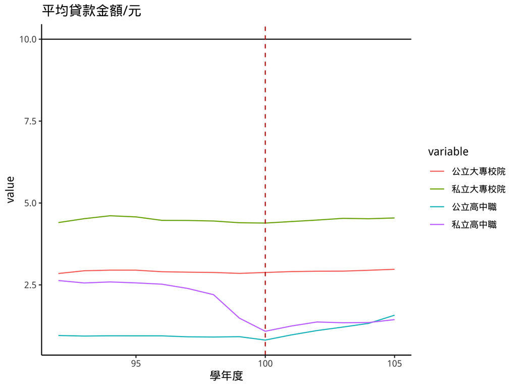

```r
graphData3
```

但graphData3的結果顯示，在100學年度起，無論公立或私立的高中職，其平均貸款金額皆明顯逐年提高，是值得我們探究其原因的結果。 ```